# Tactical RPG movement

In this series, you will learn to implement **grid-based movement, unit selection, and pathfinding** for a turn-based tactical RPG.

[video not shown]

By the end, you will have a demo where you can navigate the board using either the keyboard or the mouse, select units, and move them within some limits.

## What we’ll create

This project involves implementing all the features required to move a unit on a game board in a turn-based game.

In the final demo, the player can:

1. Move a cursor around a grid by pressing the arrow keys or using the mouse.
2. Select a unit when the cursor hovers its cell using the keyboard or the mouse.
3. Move a selected unit to another cell within its movement range.

All that giving visual feedback to the player constantly. As you could see above, we’ll draw the movement range of selected units and the path it will take to reach the target cell. We’ll also take occupied cells into account and use the AStar pathfinding algorithm.

## Handling grid interactions

There are two main ways to handle grid movement and interactions in an engine like Godot:

1. Relying on the **physics engine.** In particular, areas and ray casts.
2. Using an **object that represents the game board** and manages what’s on it.

Either can work well.

The first approach allows you to encapsulate many features on the pawns or units that move on the grid. Units can detect each-other with areas and ray casts, and they can directly interact with one another. It’s quite convenient.

However, that physics-based approach can have its limitations, depending on the game: if multiple units can move simultaneously, two might move to the same target cell, causing a conflict. You end up needing to block cells when a unit starts to move using invisible collision shapes.

Also, in a tactical-RPG like this one, you still need a way to find the path a unit can walk. For that, you need an object that knows about all the units and other obstacles on the grid.

In other words, in our case, using the physics-based approach would still require an object to represent and keep track of what’s on the game board.

That’s why we’ll use the second approach. It consists of letting an object represent and not only track but also manage the game board. That object knows where every unit is and moves them. With this model, any item on the grid becomes like a lifeless pawn rather than an independent entity.

## Code structure

Here the way we’re going to structure our code and an overview of what you’ll build in the next lessons.

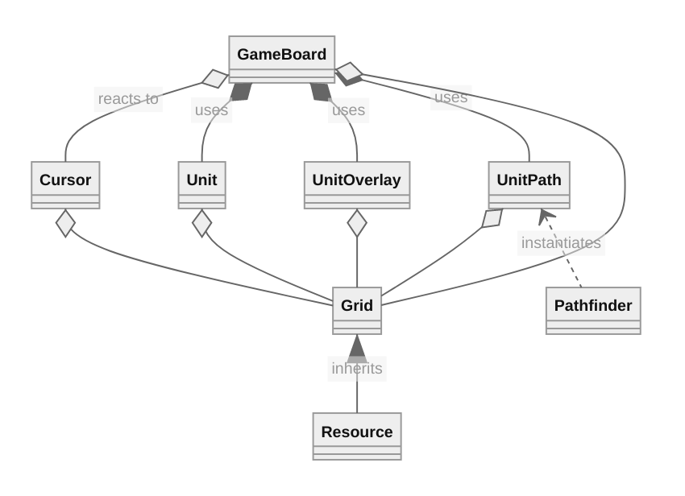

As mentioned before, we’ll use a single node to manage interactions between units, and more: the *GameBoard*. It’s going to tell units to move and generally handle “collisions”, preventing you from moving a unit to an occupied grid cell.

As usual with our projects, we favor composition: you could reuse most scripts and systems from this project in another as they don’t have strict dependencies on one another, except for the *GameBoard*.

Let’s briefly go through each component’s responsibility.

The *Cursor* is the player’s cursor, a selection tool you can move across grid cells and use to select and move units.

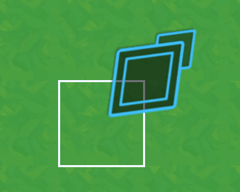

*Unit* represents one pawn on the game board. It only handles a unit’s visual aspect: animating and moving smoothly around the board. It’s the *GameBoard* that handles actual movement behind the scenes.

[figure not shown]

*UnitOverlay* draws the cells a given unit can walk to when it’s selected.

[figure not shown]

*UnitPath* displays the path a unit will move based on how the player moves their cursor after selecting a unit. It’s inspired by Fire Emblem games.

[figure not shown]

The *PathFinder* finds the best available path for the unit to walk to a target position, using the AStar algorithm. The *UnitPath* uses it to draw the path the node found.

Finally, the `Grid` is a class that extends Godot’s built-in `Resource` type. It represents the game’s grid and provides useful functions to convert coordinates from and to grid space.

It’s the first element we’re going to code in this series, as everything else depends on it.

We will then code in the order of the dependencies, starting with everything the game board needs and end the series with it.

See you in the next lesson, where you’ll get to code the `Grid` and learn why it’s a resource.